# day12

Elisa

5 March 2019

Exercises Day 12

1. Load the data “beetles.txt”:

Background: The national forest agency has asked you for advice - research has suggested that bark beetle attacks will be reduced if the climate becomes wetter under climate change, as suggested for the region we are looking at here. The forest agency measured bark beetle counts and precipitation over 20 years on 50 different plots across an altitudinal gradient.

Exercise: Analyse the data and give your conclusion regarding the effects of precipitation.

```r
beetles <- read.delim("~/mixed effect models/day12/beetles_data.txt")
```

### Investigate the data

```r
str(beetles)
```

```
## 'data.frame':    1000 obs. of  6 variables:
##  $ dataID       : int  1 2 3 4 5 6 7 8 9 10 ...
##  $ beetles      : int  18 33 1 3 27 37 2 55 0 65 ...
##  $ precipitation: num  0.18 0.7 0.57 0.17 0.94 0.94 0.13 0.83 0.47 0.55 ...
##  $ altitude     : num  0 0 0 0 0 0 0 0 0 0 ...
##  $ plot         : int  1 1 1 1 1 1 1 1 1 1 ...
##  $ year         : int  1 2 3 4 5 6 7 8 9 10 ...
```

```r
xtabs(~plot+year, beetles)
```

```
##     year
## plot 1 2 3 4 5 6 7 8 9 10 11 12 13 14 15 16 17 18 19 20
##   1  1 1 1 1 1 1 1 1 1  1  1  1  1  1  1  1  1  1  1  1
##   2  1 1 1 1 1 1 1 1 1  1  1  1  1  1  1  1  1  1  1  1
##   3  1 1 1 1 1 1 1 1 1  1  1  1  1  1  1  1  1  1  1  1
##   4  1 1 1 1 1 1 1 1 1  1  1  1  1  1  1  1  1  1  1  1
##   5  1 1 1 1 1 1 1 1 1  1  1  1  1  1  1  1  1  1  1  1
##   6  1 1 1 1 1 1 1 1 1  1  1  1  1  1  1  1  1  1  1  1
##   7  1 1 1 1 1 1 1 1 1  1  1  1  1  1  1  1  1  1  1  1
##   8  1 1 1 1 1 1 1 1 1  1  1  1  1  1  1  1  1  1  1  1
##   9  1 1 1 1 1 1 1 1 1  1  1  1  1  1  1  1  1  1  1  1
##   10 1 1 1 1 1 1 1 1 1  1  1  1  1  1  1  1  1  1  1  1
##   11 1 1 1 1 1 1 1 1 1  1  1  1  1  1  1  1  1  1  1  1
##   12 1 1 1 1 1 1 1 1 1  1  1  1  1  1  1  1  1  1  1  1
##   13 1 1 1 1 1 1 1 1 1  1  1  1  1  1  1  1  1  1  1  1
```

[output cut: 37 more lines]

some plots before starting

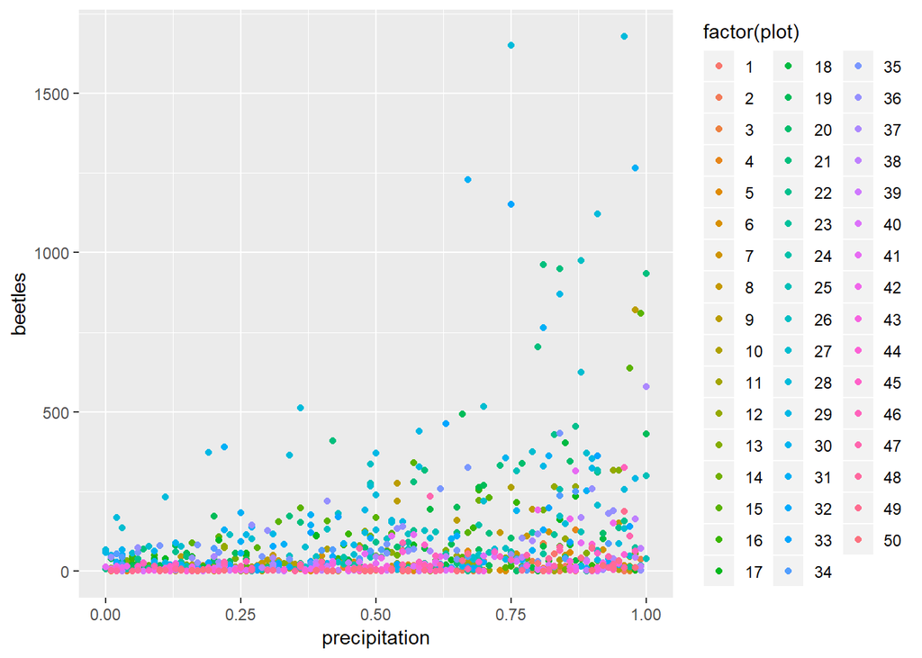

```r
beetles %>% ggplot(aes(x=precipitation, y=beetles, color=factor(plot))) +
  geom_point()
```

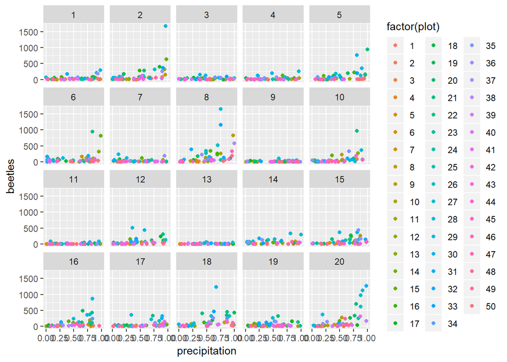

```r
beetles %>% ggplot(aes(x=precipitation, y=beetles, color=factor(plot))) +
  geom_point() +
  facet_wrap(~year)
```

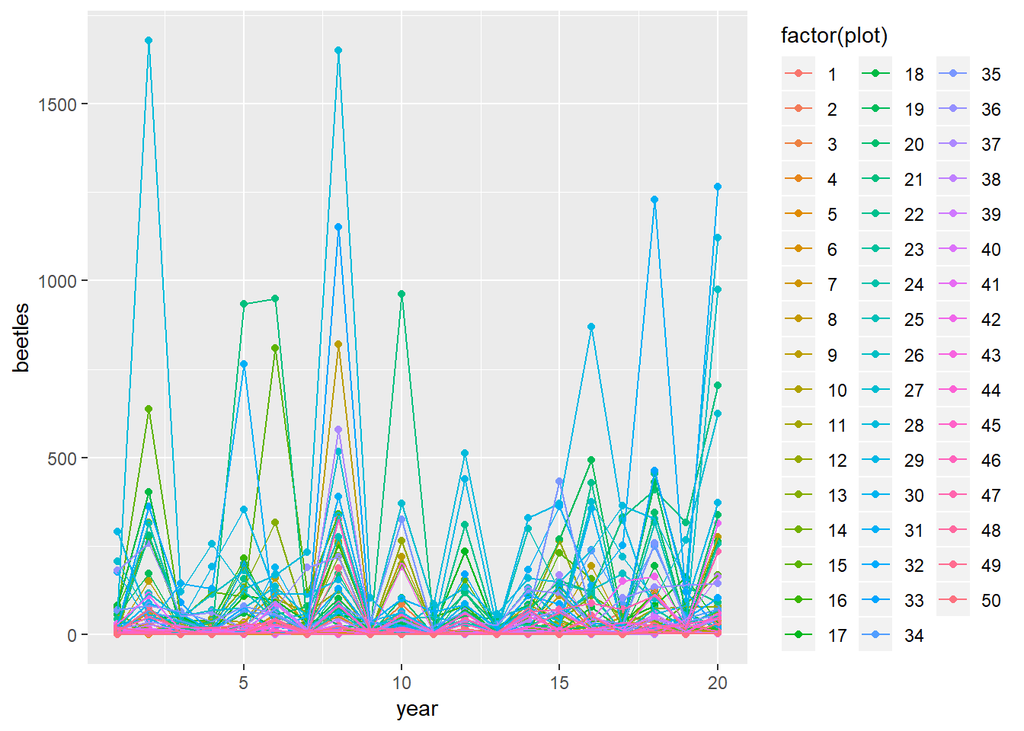

```r
beetles %>% ggplot(aes(x=year, y=beetles, group= factor(plot), color=factor(plot))) +
  geom_point()+
  geom_line()
```

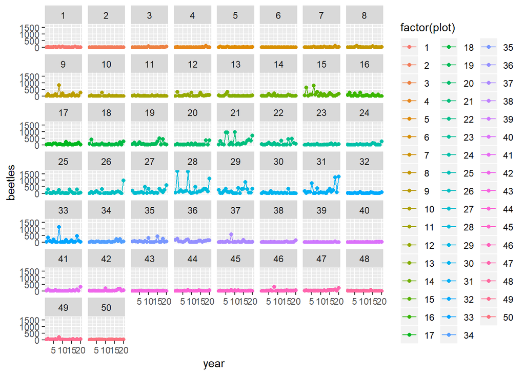

```r
beetles %>% ggplot(aes(x=year, y=beetles, group= factor(plot), color=factor(plot))) +
  geom_point()+
  geom_line()+
  facet_wrap(~plot)
```

Count data- poisson distribution.

One option is to fit a model where year is a random effect. In this case, we suppose that years are independent, and that the particular characteristichs of that year can be seen as a factor that groups the data

```r
model1 <- glmer(beetles~altitude+precipitation+(1|year)+(1|plot), family=poisson, data=beetles)
summary(model1)
```

```
## Generalized linear mixed model fit by maximum likelihood (Laplace
##   Approximation) [glmerMod]
##  Family: poisson  ( log )
## Formula: beetles ~ altitude + precipitation + (1 | year) + (1 | plot)
##    Data: beetles
##
##      AIC      BIC   logLik deviance df.resid
##  33530.2  33554.7 -16760.1  33520.2      995
##
## Scaled residuals:
##      Min       1Q   Median       3Q      Max
## -22.3057  -2.8456  -0.6346   2.3035  29.4154
##
## Random effects:
##  Groups Name        Variance Std.Dev.
##  plot   (Intercept) 1.2351   1.1113
##  year   (Intercept) 0.7809   0.8837
## Number of obs: 1000, groups:  plot, 50; year, 20
##
## Fixed effects:
##               Estimate Std. Error z value Pr(>|z|)
## (Intercept)    2.13842    0.36814   5.809 6.29e-09 ***
## altitude      -0.05204    0.53489  -0.097    0.922
## precipitation  2.27495    0.01523 149.334  < 2e-16 ***
## ---
## Signif. codes:  0 '***' 0.001 '**' 0.01 '*' 0.05 '.' 0.1 ' ' 1
##
## Correlation of Fixed Effects:
##             (Intr) altitd
## altitude    -0.727
## precipitatn -0.027 -0.001
```

```r
model1.b <- glmer(beetles~altitude+precipitation+year+(1|year)+(1|plot), family=poisson, data=beetles)
summary(model1.b)
```

```
## Generalized linear mixed model fit by maximum likelihood (Laplace
##   Approximation) [glmerMod]
##  Family: poisson  ( log )
## Formula: beetles ~ altitude + precipitation + year + (1 | year) + (1 |
##     plot)
##    Data: beetles
##
##      AIC      BIC   logLik deviance df.resid
##  33531.5  33560.9 -16759.7  33519.5      994
##
## Scaled residuals:
##      Min       1Q   Median       3Q      Max
## -22.3056  -2.8454  -0.6345   2.3030  29.4158
##
## Random effects:
##  Groups Name        Variance Std.Dev.
##  plot   (Intercept) 1.2349   1.1112
##  year   (Intercept) 0.7541   0.8684
## Number of obs: 1000, groups:  plot, 50; year, 20
##
## Fixed effects:
##               Estimate Std. Error z value Pr(>|z|)
## (Intercept)    1.84157    0.50901   3.618 0.000297 ***
## altitude      -0.05208    0.53426  -0.097 0.922349
## precipitation  2.27495    0.01523 149.334  < 2e-16 ***
## year           0.02827    0.03369   0.839 0.401309
## ---
## Signif. codes:  0 '***' 0.001 '**' 0.01 '*' 0.05 '.' 0.1 ' ' 1
##
## Correlation of Fixed Effects:
##             (Intr) altitd prcptt
## altitude    -0.525
## precipitatn -0.020 -0.001
## year        -0.695  0.000  0.000
```

Another option is to think that year might be a continious variable. We could add year as a fixed effect and allow for random slopes, for example. When trying to add the random slope the following warning appears

- Can not converge

or

- Warning message: In checkConv(attr(opt, “derivs”), opt$par, ctrl = control$checkConv, : Model is nearly unidentifiable: large eigenvalue ratio - Rescale variables?

Then we rescale the predictors, then not predictors with higher numbers are more important in the model

```r
model2 <- glmer(beetles~scale(altitude)+scale(precipitation)+scale(year)+(scale(year)|plot), family=poisson, data=beetles)
summary(model2)
```

```
## Generalized linear mixed model fit by maximum likelihood (Laplace
##   Approximation) [glmerMod]
##  Family: poisson  ( log )
## Formula: beetles ~ scale(altitude) + scale(precipitation) + scale(year) +
##     (scale(year) | plot)
##    Data: beetles
##
##      AIC      BIC   logLik deviance df.resid
##  63520.3  63554.6 -31753.1  63506.3      993
##
## Scaled residuals:
##     Min      1Q  Median      3Q     Max
## -23.558  -3.798  -1.387   2.486  71.793
##
## Random effects:
##  Groups Name        Variance Std.Dev. Corr
##  plot   (Intercept) 1.24286  1.1148
##         scale(year) 0.05779  0.2404   -0.28
## Number of obs: 1000, groups:  plot, 50
##
## Fixed effects:
##                      Estimate Std. Error z value Pr(>|z|)
## (Intercept)          3.502943   0.157821  22.196  < 2e-16 ***
## scale(altitude)      0.003076   0.151988   0.020    0.984
## scale(precipitation) 0.619284   0.004558 135.867  < 2e-16 ***
## scale(year)          0.208865   0.034720   6.016 1.79e-09 ***
## ---
## Signif. codes:  0 '***' 0.001 '**' 0.01 '*' 0.05 '.' 0.1 ' ' 1
##
## Correlation of Fixed Effects:
##             (Intr) scl(l) scl(p)
## scale(lttd)  0.000
## scl(prcptt) -0.015 -0.002
## scale(year) -0.276 -0.001  0.002
```

The random slope does not explain so much variability.

Actually, for me, looking at the data, it makes more sense to use year as a categorical ranfom effect. There is not a trend allong the years but more a particular situation each year. Year is highly significant. Then the desition on weather it is a random or fixed effects depends if it will be included between the fixed effects.

### Diagnostics of the model

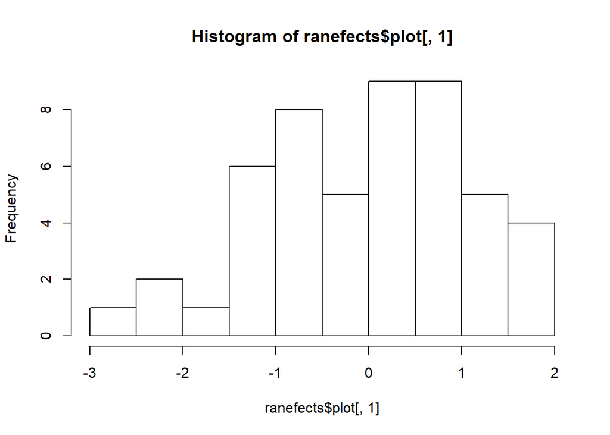

```r
ranefects <- ranef(model1) # random effects for the groups
hist(ranefects$plot[,1])
```

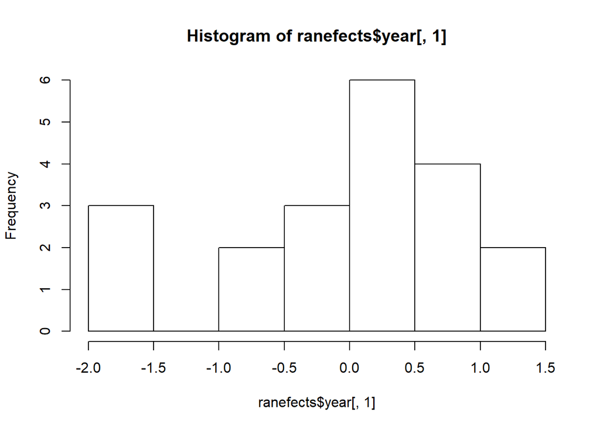

```r
hist(ranefects$year[,1]) # random effects should be normally distr+ibuted
```

```r
#qqmath(ranef(model1)) #for normality of random effects # also looks good
```

We can also check the distr+ibution fo the residuals- pearson residual

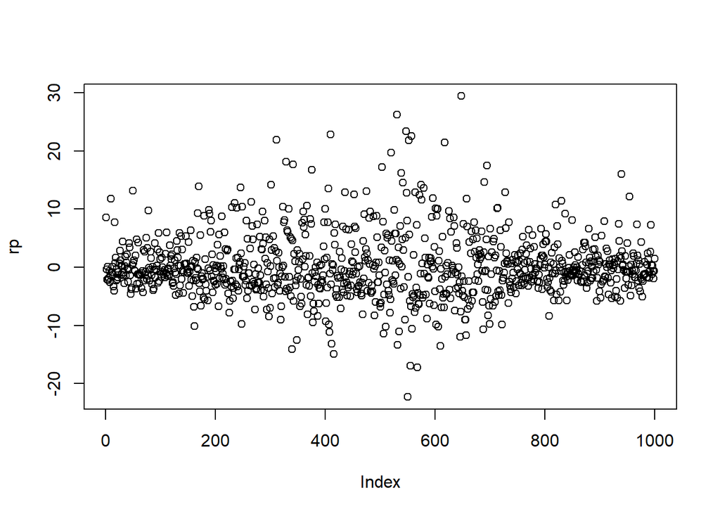

```r
# using Pearson residuals:
rp <- residuals(model1, type = "pearson") # get pearson residuals
link <- predict(model1, type = "link") # prediction on the link scale, quite overdispersed
plot(rp)
```

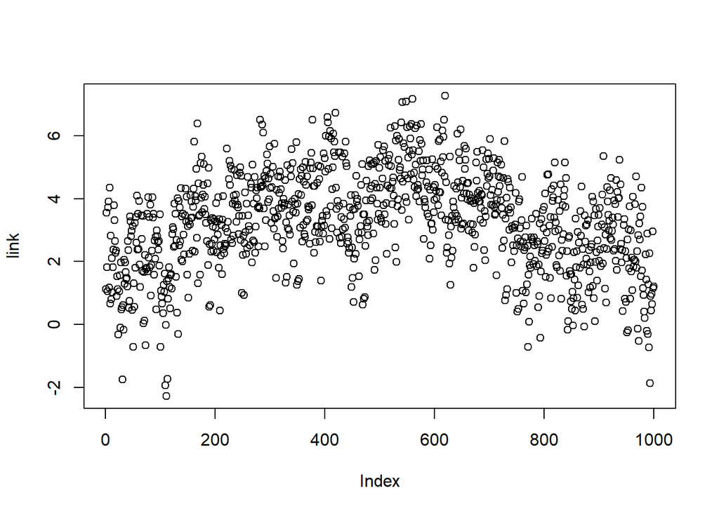

```r
plot(link)
```

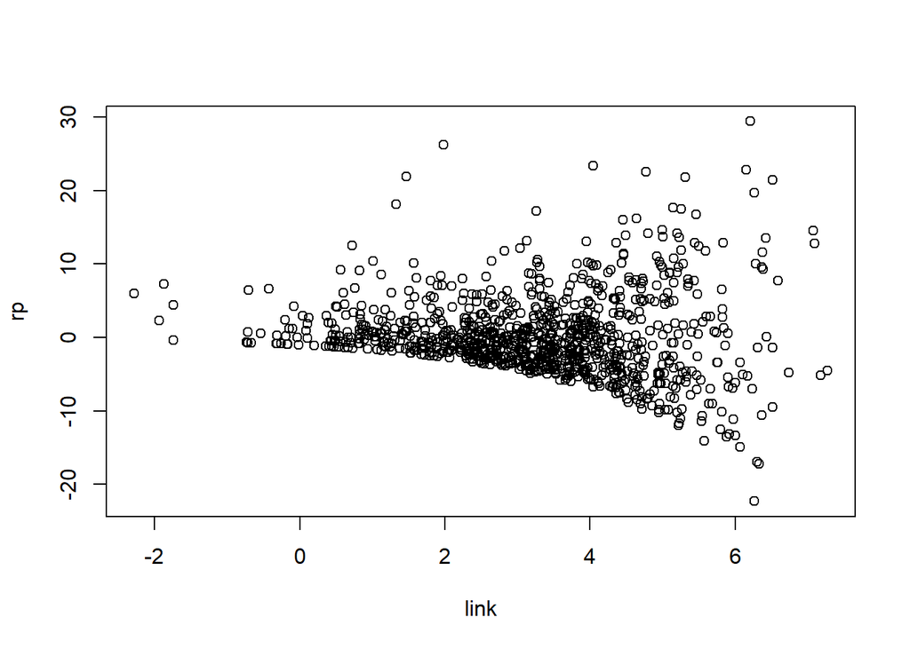

```r
plot(rp ~ link)
```

Using DAHRma package

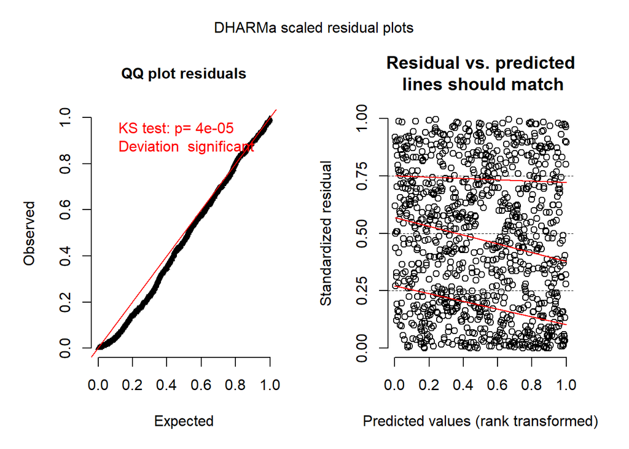

```r
out<- simulateResiduals(model1)
plot(out)
```

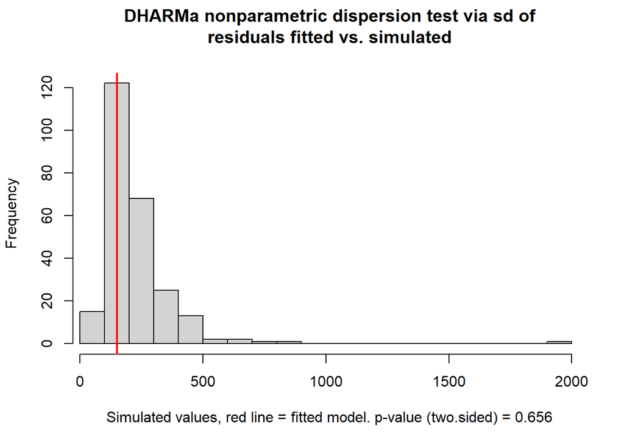

```
##
##  DHARMa nonparametric dispersion test via sd of residuals fitted
##  vs. simulated
##
## data:  simulationOutput
## ratioObsSim = 0.67508, p-value = 0.656
## alternative hypothesis: two.sided
```

```r
testDispersion(out) # not really overdispersed
```

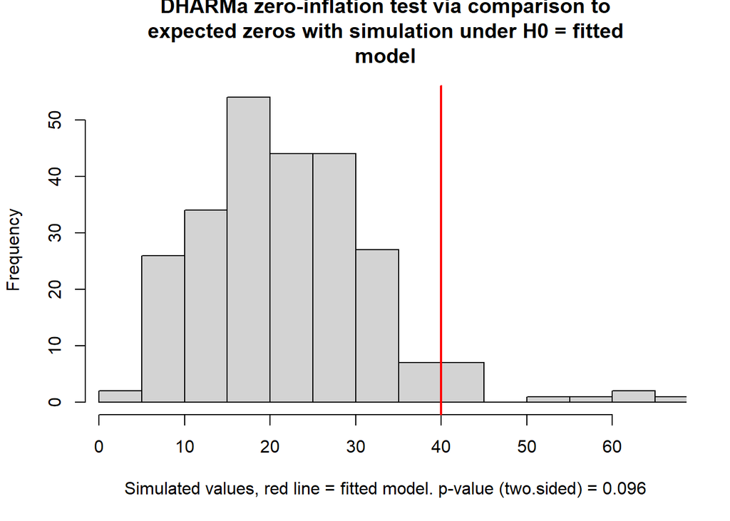

```
##
##  DHARMa zero-inflation test via comparison to expected zeros with
##  simulation under H0 = fitted model
##
## data:  simulationOutput
## ratioObsSim = 1.7784, p-value = 0.096
## alternative hypothesis: two.sided
```

```r
testZeroInflation(out) # heavily zero-inflated but not overdispersed
```

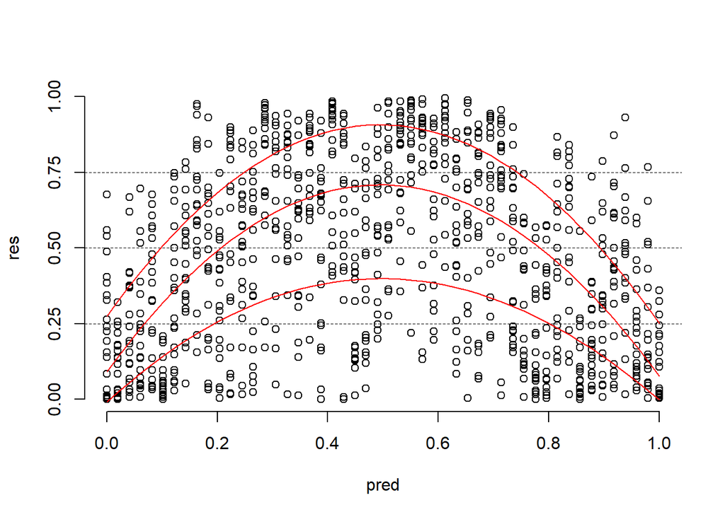

```r
plotResiduals(beetles$altitude, out$scaledResiduals) # altitude makes a problem
```

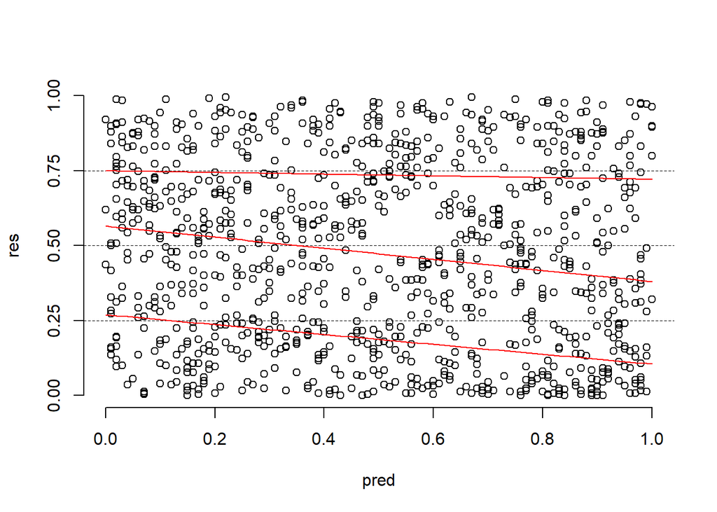

```r
plotResiduals(beetles$precipitation, out$scaledResiduals)
```

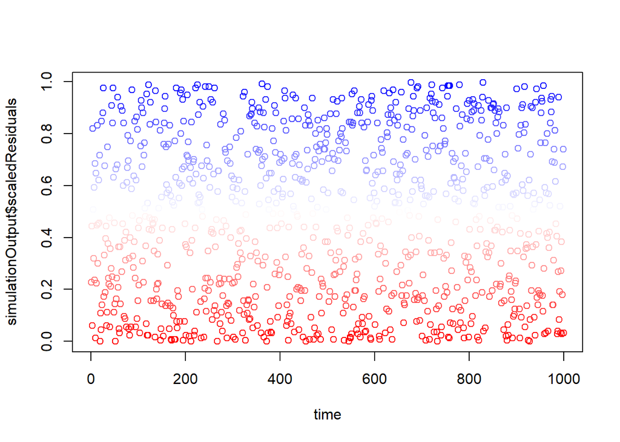

```
##
##  Durbin-Watson test
##
## data:  simulationOutput$scaledResiduals ~ 1
## DW = 2.0801, p-value = 0.2047
## alternative hypothesis: true autocorrelation is not 0
```

```r
testTemporalAutocorrelation(out) # and finally some test for temporal autocorrelation: looks good
```

there is mimsspecification of beetles altitude. LEts try adding quadratic term

```r
model2 <- glmer(beetles~poly(altitude, 2)+precipitation+(1|year)+(1|plot), family=poisson, data=beetles)
summary(model2)
```

```
## Generalized linear mixed model fit by maximum likelihood (Laplace
##   Approximation) [glmerMod]
##  Family: poisson  ( log )
## Formula: beetles ~ poly(altitude, 2) + precipitation + (1 | year) + (1 |
##     plot)
##    Data: beetles
##
##      AIC      BIC   logLik deviance df.resid
##  33490.4  33519.8 -16739.2  33478.4      994
##
## Scaled residuals:
##      Min       1Q   Median       3Q      Max
## -22.3055  -2.8460  -0.6308   2.3022  29.4127
##
## Random effects:
##  Groups Name        Variance Std.Dev.
##  plot   (Intercept) 0.5282   0.7268
##  year   (Intercept) 0.7741   0.8798
## Number of obs: 1000, groups:  plot, 50; year, 20
##
## Fixed effects:
##                     Estimate Std. Error z value Pr(>|z|)
## (Intercept)          2.11261    0.22232   9.502   <2e-16 ***
## poly(altitude, 2)1  -0.49791    3.27884  -0.152    0.879
## poly(altitude, 2)2 -26.41821    3.20404  -8.245   <2e-16 ***
## precipitation        2.27503    0.01523 149.342   <2e-16 ***
## ---
## Signif. codes:  0 '***' 0.001 '**' 0.01 '*' 0.05 '.' 0.1 ' ' 1
##
## Correlation of Fixed Effects:
##             (Intr) p(,2)1 p(,2)2
## ply(ltt,2)1  0.000
## ply(ltt,2)2  0.002  0.001
## precipitatn -0.046 -0.002 -0.001
```

The square term is significant. So lets check the model again- significant.

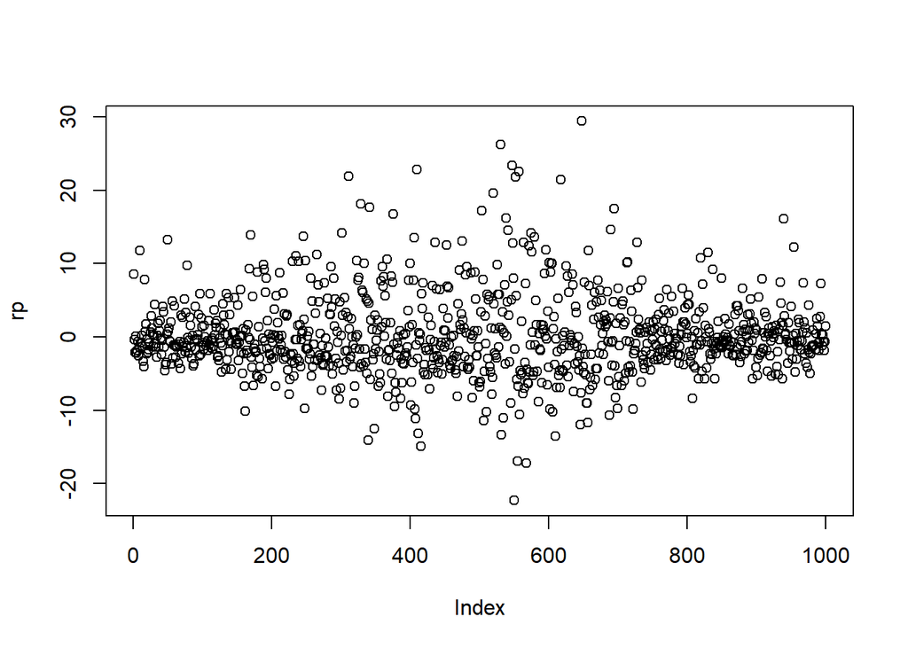

```r
# using Pearson residuals:
rp <- residuals(model2, type = "pearson") # get pearson residuals
link <- predict(model2, type = "link") # prediction on the link scale, quite overdispersed
plot(rp)
```

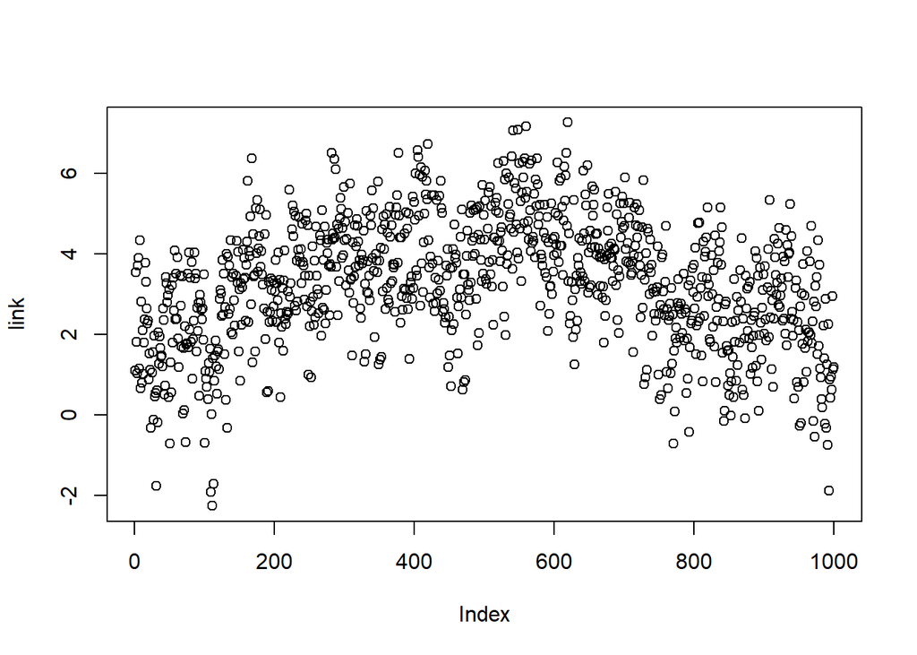

```r
plot(link)
```

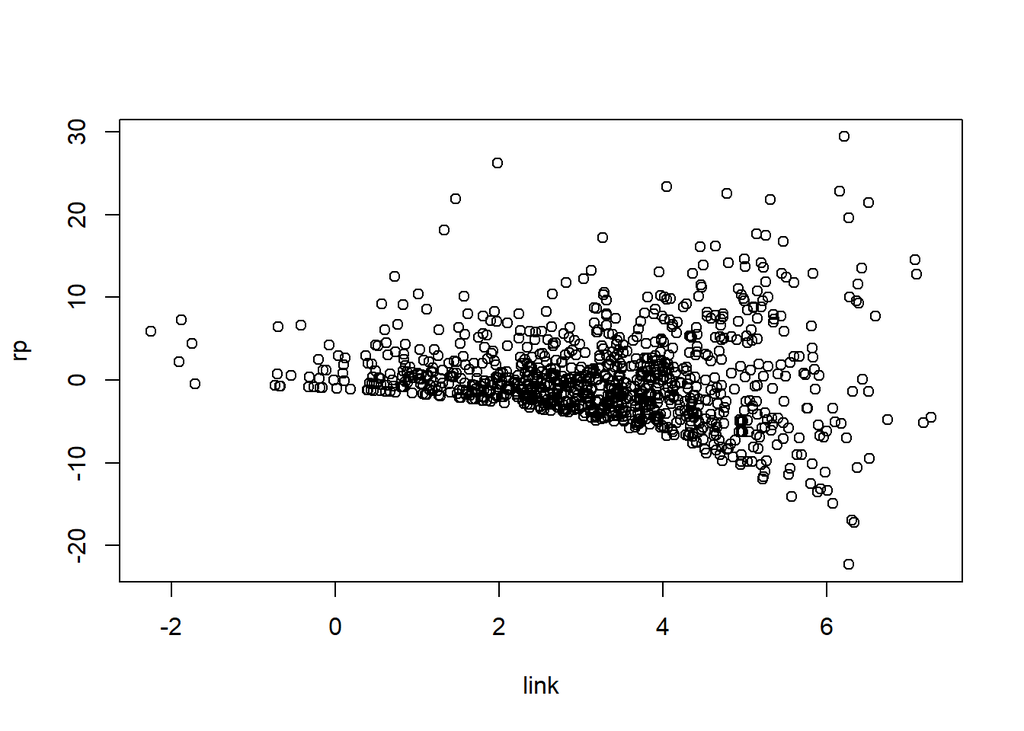

```r
plot(rp ~ link)
```

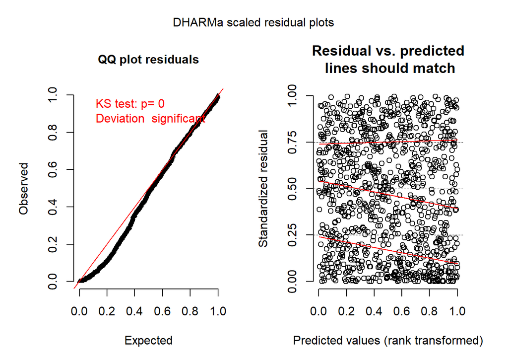

```r
out<- simulateResiduals(model2)
plot(out)
```

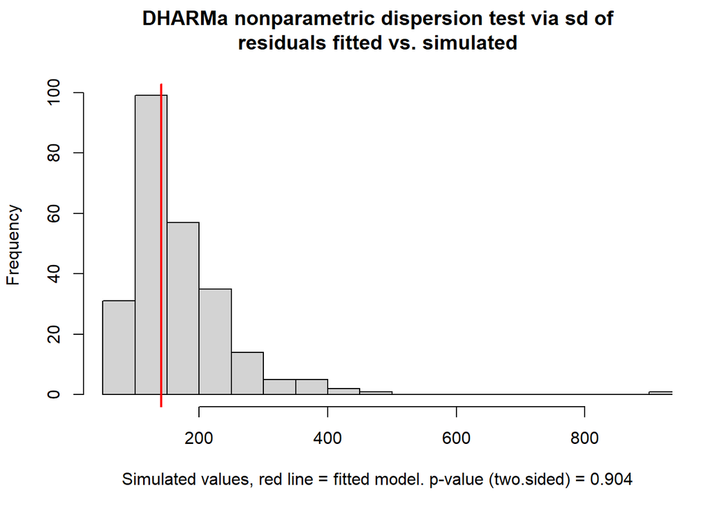

```
##
##  DHARMa nonparametric dispersion test via sd of residuals fitted
##  vs. simulated
##
## data:  simulationOutput
## ratioObsSim = 0.8402, p-value = 0.904
## alternative hypothesis: two.sided
```

```r
testDispersion(out) # not really overdispersed
```

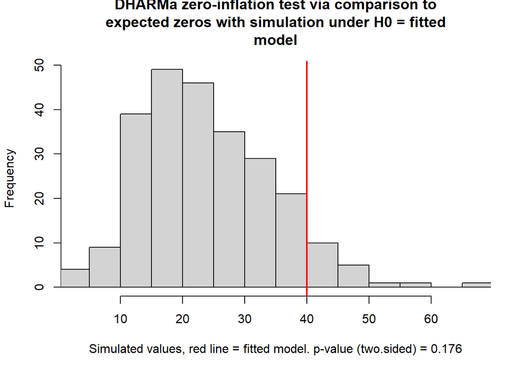

```
##
##  DHARMa zero-inflation test via comparison to expected zeros with
##  simulation under H0 = fitted model
##
## data:  simulationOutput
## ratioObsSim = 1.6447, p-value = 0.176
## alternative hypothesis: two.sided
```

```r
testZeroInflation(out) # heavily zero-inflated but not overdispersed
```

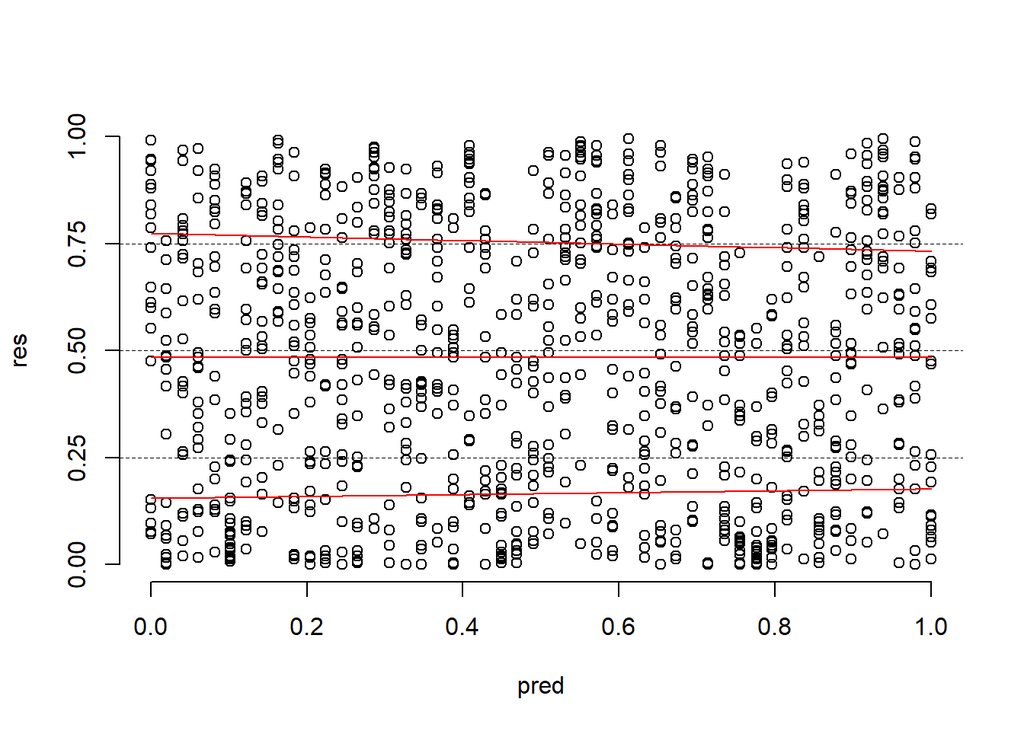

```r
plotResiduals(beetles$altitude, out$scaledResiduals) # altitude makes a problem
```

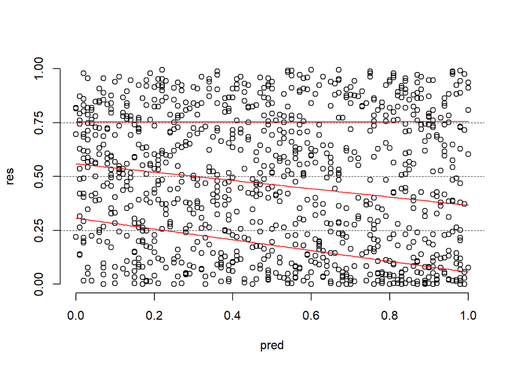

```r
plotResiduals(beetles$precipitation, out$scaledResiduals)
```

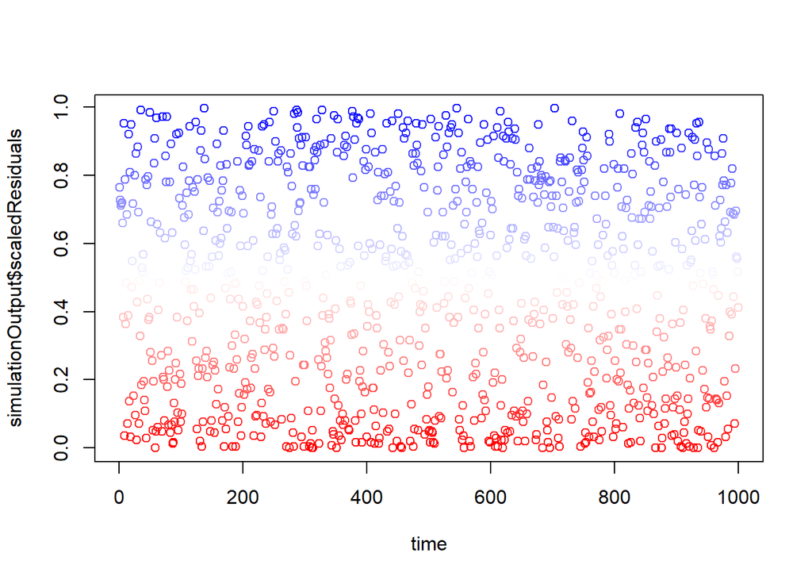

```
##
##  Durbin-Watson test
##
## data:  simulationOutput$scaledResiduals ~ 1
## DW = 2.0596, p-value = 0.3454
## alternative hypothesis: true autocorrelation is not 0
```

```r
testTemporalAutocorrelation(out)
```

# OH!!!!!! really much better naw!!!